# Risk Factor Analysis

## Outcome Variable

**Outcome Variable:** ever_stunted

## Predictor Variables

**Intervention Variable:** earlybf

**Adjustment Set:**

- arm
- W_mage
- meducyrs
- feducyrs
- hhwealth_quart
- hfoodsec
- W_mhtcm
- W_mwtkg
- W_mbmi
- vagbrth
- W_birthwt
- W_birthlen
- W_nrooms
- brthmon
- W_parity
- impfloor
- impsan
- safeh20
- delta_W_mage
- delta_meducyrs
- delta_feducyrs
- delta_hhwealth_quart
- delta_hfoodsec
- delta_W_mhtcm
- delta_W_mwtkg
- delta_W_mbmi
- delta_vagbrth
- delta_W_birthwt
- delta_W_birthlen
- delta_W_nrooms
- delta_brthmon
- delta_W_parity
- delta_impfloor
- delta_impsan
- delta_safeh20

## Stratifying Variables

The analysis was stratified on these variable(s):

- agecat
- studyid
- country

## Data Summary

| agecat | studyid | country | earlybf | ever_stunted | n_cell | n |
| --- | --- | --- | --- | --- | --- | --- |
| 0-24 months (no birth st.) | EE | PAKISTAN | 1 | 0 | 12 | 206 |
| 0-24 months (no birth st.) | EE | PAKISTAN | 1 | 1 | 31 | 206 |
| 0-24 months (no birth st.) | EE | PAKISTAN | 0 | 0 | 26 | 206 |
| 0-24 months (no birth st.) | EE | PAKISTAN | 0 | 1 | 137 | 206 |
| 0-24 months (no birth st.) | GMS-Nepal | NEPAL | 1 | 0 | 77 | 527 |
| 0-24 months (no birth st.) | GMS-Nepal | NEPAL | 1 | 1 | 77 | 527 |
| 0-24 months (no birth st.) | GMS-Nepal | NEPAL | 0 | 0 | 155 | 527 |
| 0-24 months (no birth st.) | GMS-Nepal | NEPAL | 0 | 1 | 218 | 527 |
| 0-24 months (no birth st.) | JiVitA-3 | BANGLADESH | 1 | 0 | 79 | 18308 |
| 0-24 months (no birth st.) | JiVitA-3 | BANGLADESH | 1 | 1 | 17 | 18308 |
| 0-24 months (no birth st.) | JiVitA-3 | BANGLADESH | 0 | 0 | 13594 | 18308 |
| 0-24 months (no birth st.) | JiVitA-3 | BANGLADESH | 0 | 1 | 4618 | 18308 |
| 0-24 months (no birth st.) | JiVitA-4 | BANGLADESH | 1 | 0 | 1421 | 3886 |
| 0-24 months (no birth st.) | JiVitA-4 | BANGLADESH | 1 | 1 | 1056 | 3886 |
| 0-24 months (no birth st.) | JiVitA-4 | BANGLADESH | 0 | 0 | 858 | 3886 |
| 0-24 months (no birth st.) | JiVitA-4 | BANGLADESH | 0 | 1 | 551 | 3886 |
| 0-24 months (no birth st.) | MAL-ED | BANGLADESH | 1 | 0 | 65 | 216 |
| 0-24 months (no birth st.) | MAL-ED | BANGLADESH | 1 | 1 | 73 | 216 |
| 0-24 months (no birth st.) | MAL-ED | BANGLADESH | 0 | 0 | 38 | 216 |
| 0-24 months (no birth st.) | MAL-ED | BANGLADESH | 0 | 1 | 40 | 216 |
| 0-24 months (no birth st.) | MAL-ED | BRAZIL | 1 | 0 | 78 | 202 |
| 0-24 months (no birth st.) | MAL-ED | BRAZIL | 1 | 1 | 17 | 202 |
| 0-24 months (no birth st.) | MAL-ED | BRAZIL | 0 | 0 | 92 | 202 |
| 0-24 months (no birth st.) | MAL-ED | BRAZIL | 0 | 1 | 15 | 202 |
| 0-24 months (no birth st.) | MAL-ED | INDIA | 1 | 0 | 61 | 209 |
| 0-24 months (no birth st.) | MAL-ED | INDIA | 1 | 1 | 66 | 209 |
| 0-24 months (no birth st.) | MAL-ED | INDIA | 0 | 0 | 37 | 209 |
| 0-24 months (no birth st.) | MAL-ED | INDIA | 0 | 1 | 45 | 209 |
| 0-24 months (no birth st.) | MAL-ED | NEPAL | 1 | 0 | 65 | 211 |
| 0-24 months (no birth st.) | MAL-ED | NEPAL | 1 | 1 | 25 | 211 |

[output cut: 138 more lines]

The following strata were considered:

- agecat: 0-24 months (no birth st.), studyid: EE, country: PAKISTAN
- agecat: 0-24 months (no birth st.), studyid: GMS-Nepal, country: NEPAL
- agecat: 0-24 months (no birth st.), studyid: JiVitA-3, country: BANGLADESH
- agecat: 0-24 months (no birth st.), studyid: JiVitA-4, country: BANGLADESH
- agecat: 0-24 months (no birth st.), studyid: MAL-ED, country: BANGLADESH
- agecat: 0-24 months (no birth st.), studyid: MAL-ED, country: BRAZIL
- agecat: 0-24 months (no birth st.), studyid: MAL-ED, country: INDIA
- agecat: 0-24 months (no birth st.), studyid: MAL-ED, country: NEPAL
- agecat: 0-24 months (no birth st.), studyid: MAL-ED, country: PERU
- agecat: 0-24 months (no birth st.), studyid: MAL-ED, country: SOUTH AFRICA
- agecat: 0-24 months (no birth st.), studyid: MAL-ED, country: TANZANIA, UNITED REPUBLIC OF
- agecat: 0-24 months (no birth st.), studyid: NIH-Crypto, country: BANGLADESH
- agecat: 0-24 months (no birth st.), studyid: SAS-CompFeed, country: INDIA
- agecat: 0-24 months (no birth st.), studyid: ZVITAMBO, country: ZIMBABWE
- agecat: 0-6 months (no birth st.), studyid: EE, country: PAKISTAN
- agecat: 0-6 months (no birth st.), studyid: GMS-Nepal, country: NEPAL
- agecat: 0-6 months (no birth st.), studyid: JiVitA-3, country: BANGLADESH
- agecat: 0-6 months (no birth st.), studyid: JiVitA-4, country: BANGLADESH
- agecat: 0-6 months (no birth st.), studyid: MAL-ED, country: BANGLADESH
- agecat: 0-6 months (no birth st.), studyid: MAL-ED, country: BRAZIL
- agecat: 0-6 months (no birth st.), studyid: MAL-ED, country: INDIA
- agecat: 0-6 months (no birth st.), studyid: MAL-ED, country: NEPAL
- agecat: 0-6 months (no birth st.), studyid: MAL-ED, country: PERU
- agecat: 0-6 months (no birth st.), studyid: MAL-ED, country: SOUTH AFRICA
- agecat: 0-6 months (no birth st.), studyid: MAL-ED, country: TANZANIA, UNITED REPUBLIC OF
- agecat: 0-6 months (no birth st.), studyid: NIH-Crypto, country: BANGLADESH
- agecat: 0-6 months (no birth st.), studyid: SAS-CompFeed, country: INDIA
- agecat: 0-6 months (no birth st.), studyid: ZVITAMBO, country: ZIMBABWE
- agecat: 6-24 months, studyid: EE, country: PAKISTAN
- agecat: 6-24 months, studyid: GMS-Nepal, country: NEPAL
- agecat: 6-24 months, studyid: JiVitA-3, country: BANGLADESH
- agecat: 6-24 months, studyid: JiVitA-4, country: BANGLADESH
- agecat: 6-24 months, studyid: MAL-ED, country: BANGLADESH
- agecat: 6-24 months, studyid: MAL-ED, country: BRAZIL
- agecat: 6-24 months, studyid: MAL-ED, country: INDIA
- agecat: 6-24 months, studyid: MAL-ED, country: NEPAL
- agecat: 6-24 months, studyid: MAL-ED, country: PERU
- agecat: 6-24 months, studyid: MAL-ED, country: SOUTH AFRICA
- agecat: 6-24 months, studyid: MAL-ED, country: TANZANIA, UNITED REPUBLIC OF
- agecat: 6-24 months, studyid: NIH-Crypto, country: BANGLADESH
- agecat: 6-24 months, studyid: SAS-CompFeed, country: INDIA
- agecat: 6-24 months, studyid: ZVITAMBO, country: ZIMBABWE

### Dropped Strata

Some strata were dropped due to rare outcomes:

- agecat: 6-24 months, studyid: JiVitA-3, country: BANGLADESH

## Methods Detail

We’re interested in the causal parameters $E[Y_a]$ for all values of $a \in \mathcal{A}$. These parameters represent the mean outcome if, possibly contrary to fact, we intervened to set all units to have $A=a$. Under the randomization and positivity assumptions, these are identified by the statistical parameters $\psi_a=E_W[E_{Y|A,W}(Y|A=a,W)]$. In addition, we’re interested in the mean of $Y$, $E[Y]$ under no intervention (the observed mean). We will estimate these parameters by using SuperLearner to fit the relevant likelihood factors – $E_{Y|A,W}(Y|A=a,W)$ and $p(A=a|W)$, and then updating our likelihood fit using a joint TMLE.

For unadjusted analyses ($W=\{\}$), initial likelihoods were estimated using Lrnr_glm to estimate the simple $E(Y|A)$ and Lrnr_mean to estimate $p(A)$. For adjusted analyses, a small library containing Lrnr_glmnet, Lrnr_xgboost, and Lrnr_mean was used.

Having estimated these parameters, we will then use the delta method to estimate relative risks and attributable risks relative to a prespecified baseline level of $A$.

# Results Detail

## Results Plots

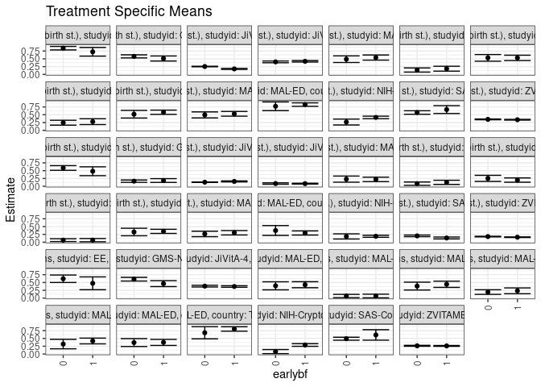

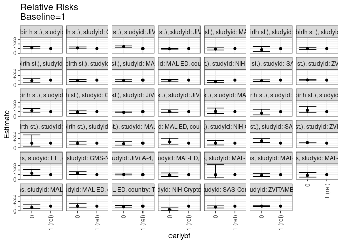

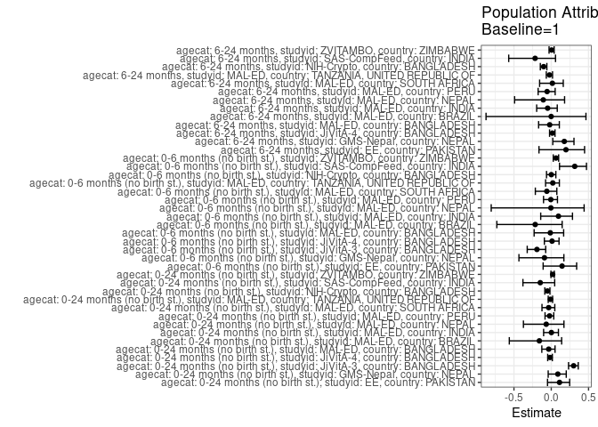

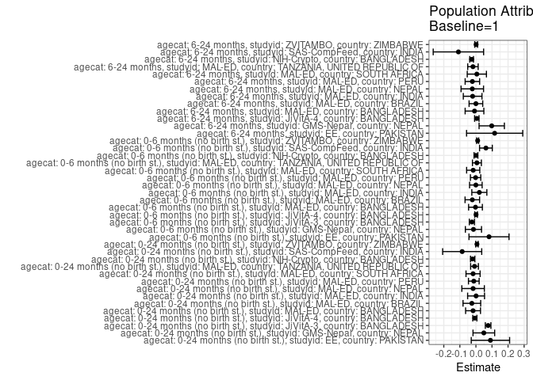

## Results Table

### Parameter: TSM

| agecat | studyid | country | intervention_level | baseline_level | estimate | ci_lower | ci_upper |
| --- | --- | --- | --- | --- | --- | --- | --- |
| 0-24 months (no birth st.) | EE | PAKISTAN | 1 | NA | 0.7252023 | 0.5866697 | 0.8637350 |
| 0-24 months (no birth st.) | EE | PAKISTAN | 0 | NA | 0.8413303 | 0.7848507 | 0.8978099 |
| 0-24 months (no birth st.) | GMS-Nepal | NEPAL | 1 | NA | 0.5105145 | 0.4297479 | 0.5912811 |
| 0-24 months (no birth st.) | GMS-Nepal | NEPAL | 0 | NA | 0.5783057 | 0.5288520 | 0.6277594 |
| 0-24 months (no birth st.) | JiVitA-3 | BANGLADESH | 1 | NA | 0.1772045 | 0.1613927 | 0.1930162 |
| 0-24 months (no birth st.) | JiVitA-3 | BANGLADESH | 0 | NA | 0.2535655 | 0.2456240 | 0.2615071 |
| 0-24 months (no birth st.) | JiVitA-4 | BANGLADESH | 1 | NA | 0.4201571 | 0.3967537 | 0.4435605 |
| 0-24 months (no birth st.) | JiVitA-4 | BANGLADESH | 0 | NA | 0.4019644 | 0.3735261 | 0.4304028 |
| 0-24 months (no birth st.) | MAL-ED | BANGLADESH | 1 | NA | 0.5409769 | 0.4589493 | 0.6230045 |
| 0-24 months (no birth st.) | MAL-ED | BANGLADESH | 0 | NA | 0.4882125 | 0.3825058 | 0.5939192 |
| 0-24 months (no birth st.) | MAL-ED | BRAZIL | 1 | NA | 0.1836976 | 0.1053838 | 0.2620115 |
| 0-24 months (no birth st.) | MAL-ED | BRAZIL | 0 | NA | 0.1416136 | 0.0754143 | 0.2078129 |
| 0-24 months (no birth st.) | MAL-ED | INDIA | 1 | NA | 0.5301046 | 0.4440315 | 0.6161778 |
| 0-24 months (no birth st.) | MAL-ED | INDIA | 0 | NA | 0.5310205 | 0.4241863 | 0.6378546 |
| 0-24 months (no birth st.) | MAL-ED | NEPAL | 1 | NA | 0.2782303 | 0.1850617 | 0.3713988 |
| 0-24 months (no birth st.) | MAL-ED | NEPAL | 0 | NA | 0.2451416 | 0.1673067 | 0.3229765 |
| 0-24 months (no birth st.) | MAL-ED | PERU | 1 | NA | 0.5808269 | 0.5126432 | 0.6490107 |
| 0-24 months (no birth st.) | MAL-ED | PERU | 0 | NA | 0.5171396 | 0.3943495 | 0.6399298 |
| 0-24 months (no birth st.) | MAL-ED | SOUTH AFRICA | 1 | NA | 0.5293531 | 0.4536531 | 0.6050531 |
| 0-24 months (no birth st.) | MAL-ED | SOUTH AFRICA | 0 | NA | 0.4945968 | 0.3982236 | 0.5909701 |
| 0-24 months (no birth st.) | MAL-ED | TANZANIA, UNITED REPUBLIC OF | 1 | NA | 0.8260870 | 0.7711946 | 0.8809793 |
| 0-24 months (no birth st.) | MAL-ED | TANZANIA, UNITED REPUBLIC OF | 0 | NA | 0.7714286 | 0.6319952 | 0.9108619 |
| 0-24 months (no birth st.) | NIH-Crypto | BANGLADESH | 1 | NA | 0.4138309 | 0.3735090 | 0.4541527 |
| 0-24 months (no birth st.) | NIH-Crypto | BANGLADESH | 0 | NA | 0.2667634 | 0.1724507 | 0.3610761 |
| 0-24 months (no birth st.) | SAS-CompFeed | INDIA | 1 | NA | 0.6658856 | 0.5399571 | 0.7918141 |
| 0-24 months (no birth st.) | SAS-CompFeed | INDIA | 0 | NA | 0.5722453 | 0.5162156 | 0.6282749 |
| 0-24 months (no birth st.) | ZVITAMBO | ZIMBABWE | 1 | NA | 0.3400651 | 0.3282707 | 0.3518595 |
| 0-24 months (no birth st.) | ZVITAMBO | ZIMBABWE | 0 | NA | 0.3520382 | 0.3393570 | 0.3647194 |
| 0-6 months (no birth st.) | EE | PAKISTAN | 1 | NA | 0.4815665 | 0.3395454 | 0.6235876 |
| 0-6 months (no birth st.) | EE | PAKISTAN | 0 | NA | 0.5859895 | 0.5110362 | 0.6609428 |

[output cut: 52 more lines]

### Parameter: E(Y)

| agecat | studyid | country | intervention_level | baseline_level | estimate | ci_lower | ci_upper |
| --- | --- | --- | --- | --- | --- | --- | --- |
| 0-24 months (no birth st.) | EE | PAKISTAN | NA | NA | 0.8155340 | 0.7624394 | 0.8686286 |
| 0-24 months (no birth st.) | GMS-Nepal | NEPAL | NA | NA | 0.5597723 | 0.5173495 | 0.6021951 |
| 0-24 months (no birth st.) | JiVitA-3 | BANGLADESH | NA | NA | 0.2531680 | 0.2454102 | 0.2609258 |
| 0-24 months (no birth st.) | JiVitA-4 | BANGLADESH | NA | NA | 0.4135358 | 0.3953404 | 0.4317312 |
| 0-24 months (no birth st.) | MAL-ED | BANGLADESH | NA | NA | 0.5231481 | 0.4563856 | 0.5899107 |
| 0-24 months (no birth st.) | MAL-ED | BRAZIL | NA | NA | 0.1584158 | 0.1079383 | 0.2088934 |
| 0-24 months (no birth st.) | MAL-ED | INDIA | NA | NA | 0.5311005 | 0.4632825 | 0.5989184 |
| 0-24 months (no birth st.) | MAL-ED | NEPAL | NA | NA | 0.2606635 | 0.2012891 | 0.3200380 |
| 0-24 months (no birth st.) | MAL-ED | PERU | NA | NA | 0.5676692 | 0.5080232 | 0.6273151 |
| 0-24 months (no birth st.) | MAL-ED | SOUTH AFRICA | NA | NA | 0.5115385 | 0.4506616 | 0.5724154 |
| 0-24 months (no birth st.) | MAL-ED | TANZANIA, UNITED REPUBLIC OF | NA | NA | 0.8173516 | 0.7660617 | 0.8686415 |
| 0-24 months (no birth st.) | NIH-Crypto | BANGLADESH | NA | NA | 0.3935681 | 0.3560687 | 0.4310676 |
| 0-24 months (no birth st.) | SAS-CompFeed | INDIA | NA | NA | 0.5804327 | 0.5278252 | 0.6330403 |
| 0-24 months (no birth st.) | ZVITAMBO | ZIMBABWE | NA | NA | 0.3465550 | 0.3377489 | 0.3553610 |
| 0-6 months (no birth st.) | EE | PAKISTAN | NA | NA | 0.5631068 | 0.4952092 | 0.6310044 |
| 0-6 months (no birth st.) | GMS-Nepal | NEPAL | NA | NA | 0.1688805 | 0.1368637 | 0.2008972 |
| 0-6 months (no birth st.) | JiVitA-3 | BANGLADESH | NA | NA | 0.1307419 | 0.1251476 | 0.1363361 |
| 0-6 months (no birth st.) | JiVitA-4 | BANGLADESH | NA | NA | 0.0855425 | 0.0741829 | 0.0969021 |
| 0-6 months (no birth st.) | MAL-ED | BANGLADESH | NA | NA | 0.2175926 | 0.1624398 | 0.2727454 |
| 0-6 months (no birth st.) | MAL-ED | BRAZIL | NA | NA | 0.1039604 | 0.0617667 | 0.1461541 |
| 0-6 months (no birth st.) | MAL-ED | INDIA | NA | NA | 0.2200957 | 0.1637912 | 0.2764002 |
| 0-6 months (no birth st.) | MAL-ED | NEPAL | NA | NA | 0.0663507 | 0.0326877 | 0.1000137 |
| 0-6 months (no birth st.) | MAL-ED | PERU | NA | NA | 0.3458647 | 0.2885967 | 0.4031327 |
| 0-6 months (no birth st.) | MAL-ED | SOUTH AFRICA | NA | NA | 0.2846154 | 0.2296617 | 0.3395691 |
| 0-6 months (no birth st.) | MAL-ED | TANZANIA, UNITED REPUBLIC OF | NA | NA | 0.3013699 | 0.2404592 | 0.3622805 |
| 0-6 months (no birth st.) | NIH-Crypto | BANGLADESH | NA | NA | 0.1898928 | 0.1597870 | 0.2199986 |
| 0-6 months (no birth st.) | SAS-CompFeed | INDIA | NA | NA | 0.1977401 | 0.1736271 | 0.2218531 |
| 0-6 months (no birth st.) | ZVITAMBO | ZIMBABWE | NA | NA | 0.1710972 | 0.1641255 | 0.1780689 |
| 6-24 months | EE | PAKISTAN | NA | NA | 0.5909091 | 0.4875952 | 0.6942230 |
| 6-24 months | GMS-Nepal | NEPAL | NA | NA | 0.5628415 | 0.5119537 | 0.6137294 |
| 6-24 months | JiVitA-4 | BANGLADESH | NA | NA | 0.3779118 | 0.3593176 | 0.3965059 |
| 6-24 months | MAL-ED | BANGLADESH | NA | NA | 0.4203822 | 0.3429219 | 0.4978424 |
| 6-24 months | MAL-ED | BRAZIL | NA | NA | 0.0674847 | 0.0288550 | 0.1061143 |
| 6-24 months | MAL-ED | INDIA | NA | NA | 0.4220779 | 0.3438191 | 0.5003367 |
| 6-24 months | MAL-ED | NEPAL | NA | NA | 0.2113402 | 0.1537425 | 0.2689379 |
| 6-24 months | MAL-ED | PERU | NA | NA | 0.3959732 | 0.3171819 | 0.4747644 |
| 6-24 months | MAL-ED | SOUTH AFRICA | NA | NA | 0.3782051 | 0.3018621 | 0.4545482 |
| 6-24 months | MAL-ED | TANZANIA, UNITED REPUBLIC OF | NA | NA | 0.7847222 | 0.7173567 | 0.8520877 |
| 6-24 months | NIH-Crypto | BANGLADESH | NA | NA | 0.2628458 | 0.2244546 | 0.3012371 |
| 6-24 months | SAS-CompFeed | INDIA | NA | NA | 0.5030750 | 0.4588491 | 0.5473009 |
| 6-24 months | ZVITAMBO | ZIMBABWE | NA | NA | 0.2616179 | 0.2517052 | 0.2715306 |

### Parameter: RR

| agecat | studyid | country | intervention_level | baseline_level | estimate | ci_lower | ci_upper |
| --- | --- | --- | --- | --- | --- | --- | --- |
| 0-24 months (no birth st.) | EE | PAKISTAN | 1 | 1 | 1.0000000 | 1.0000000 | 1.0000000 |
| 0-24 months (no birth st.) | EE | PAKISTAN | 0 | 1 | 1.1601318 | 0.9475248 | 1.4204438 |
| 0-24 months (no birth st.) | GMS-Nepal | NEPAL | 1 | 1 | 1.0000000 | 1.0000000 | 1.0000000 |
| 0-24 months (no birth st.) | GMS-Nepal | NEPAL | 0 | 1 | 1.1327899 | 0.9482587 | 1.3532310 |
| 0-24 months (no birth st.) | JiVitA-3 | BANGLADESH | 1 | 1 | 1.0000000 | 1.0000000 | 1.0000000 |
| 0-24 months (no birth st.) | JiVitA-3 | BANGLADESH | 0 | 1 | 1.4309206 | 1.3019010 | 1.5727262 |
| 0-24 months (no birth st.) | JiVitA-4 | BANGLADESH | 1 | 1 | 1.0000000 | 1.0000000 | 1.0000000 |
| 0-24 months (no birth st.) | JiVitA-4 | BANGLADESH | 0 | 1 | 0.9567004 | 0.8756957 | 1.0451982 |
| 0-24 months (no birth st.) | MAL-ED | BANGLADESH | 1 | 1 | 1.0000000 | 1.0000000 | 1.0000000 |
| 0-24 months (no birth st.) | MAL-ED | BANGLADESH | 0 | 1 | 0.9024647 | 0.7004164 | 1.1627976 |
| 0-24 months (no birth st.) | MAL-ED | BRAZIL | 1 | 1 | 1.0000000 | 1.0000000 | 1.0000000 |
| 0-24 months (no birth st.) | MAL-ED | BRAZIL | 0 | 1 | 0.7709060 | 0.4083950 | 1.4551992 |
| 0-24 months (no birth st.) | MAL-ED | INDIA | 1 | 1 | 1.0000000 | 1.0000000 | 1.0000000 |
| 0-24 months (no birth st.) | MAL-ED | INDIA | 0 | 1 | 1.0017276 | 0.7776869 | 1.2903114 |
| 0-24 months (no birth st.) | MAL-ED | NEPAL | 1 | 1 | 1.0000000 | 1.0000000 | 1.0000000 |
| 0-24 months (no birth st.) | MAL-ED | NEPAL | 0 | 1 | 0.8810745 | 0.5551803 | 1.3982705 |
| 0-24 months (no birth st.) | MAL-ED | PERU | 1 | 1 | 1.0000000 | 1.0000000 | 1.0000000 |
| 0-24 months (no birth st.) | MAL-ED | PERU | 0 | 1 | 0.8903506 | 0.6843643 | 1.1583367 |
| 0-24 months (no birth st.) | MAL-ED | SOUTH AFRICA | 1 | 1 | 1.0000000 | 1.0000000 | 1.0000000 |
| 0-24 months (no birth st.) | MAL-ED | SOUTH AFRICA | 0 | 1 | 0.9343420 | 0.7386375 | 1.1818992 |
| 0-24 months (no birth st.) | MAL-ED | TANZANIA, UNITED REPUBLIC OF | 1 | 1 | 1.0000000 | 1.0000000 | 1.0000000 |
| 0-24 months (no birth st.) | MAL-ED | TANZANIA, UNITED REPUBLIC OF | 0 | 1 | 0.9338346 | 0.7702576 | 1.1321499 |
| 0-24 months (no birth st.) | NIH-Crypto | BANGLADESH | 1 | 1 | 1.0000000 | 1.0000000 | 1.0000000 |
| 0-24 months (no birth st.) | NIH-Crypto | BANGLADESH | 0 | 1 | 0.6446194 | 0.4475917 | 0.9283777 |
| 0-24 months (no birth st.) | SAS-CompFeed | INDIA | 1 | 1 | 1.0000000 | 1.0000000 | 1.0000000 |
| 0-24 months (no birth st.) | SAS-CompFeed | INDIA | 0 | 1 | 0.8593748 | 0.7038594 | 1.0492508 |
| 0-24 months (no birth st.) | ZVITAMBO | ZIMBABWE | 1 | 1 | 1.0000000 | 1.0000000 | 1.0000000 |
| 0-24 months (no birth st.) | ZVITAMBO | ZIMBABWE | 0 | 1 | 1.0352082 | 0.9864962 | 1.0863256 |
| 0-6 months (no birth st.) | EE | PAKISTAN | 1 | 1 | 1.0000000 | 1.0000000 | 1.0000000 |
| 0-6 months (no birth st.) | EE | PAKISTAN | 0 | 1 | 1.2168403 | 0.8883487 | 1.6668008 |

[output cut: 52 more lines]

### Parameter: PAR

| agecat | studyid | country | intervention_level | baseline_level | estimate | ci_lower | ci_upper |
| --- | --- | --- | --- | --- | --- | --- | --- |
| 0-24 months (no birth st.) | EE | PAKISTAN | 1 | NA | 0.0903316 | -0.0290511 | 0.2097144 |
| 0-24 months (no birth st.) | GMS-Nepal | NEPAL | 1 | NA | 0.0492578 | -0.0180997 | 0.1166153 |
| 0-24 months (no birth st.) | JiVitA-3 | BANGLADESH | 1 | NA | 0.0759635 | 0.0587362 | 0.0931909 |
| 0-24 months (no birth st.) | JiVitA-4 | BANGLADESH | 1 | NA | -0.0066213 | -0.0195209 | 0.0062783 |
| 0-24 months (no birth st.) | MAL-ED | BANGLADESH | 1 | NA | -0.0178287 | -0.0641491 | 0.0284916 |
| 0-24 months (no birth st.) | MAL-ED | BRAZIL | 1 | NA | -0.0252818 | -0.0802770 | 0.0297134 |
| 0-24 months (no birth st.) | MAL-ED | INDIA | 1 | NA | 0.0009958 | -0.0516173 | 0.0536090 |
| 0-24 months (no birth st.) | MAL-ED | NEPAL | 1 | NA | -0.0175668 | -0.0876313 | 0.0524978 |
| 0-24 months (no birth st.) | MAL-ED | PERU | 1 | NA | -0.0131578 | -0.0463423 | 0.0200268 |
| 0-24 months (no birth st.) | MAL-ED | SOUTH AFRICA | 1 | NA | -0.0178146 | -0.0617318 | 0.0261026 |
| 0-24 months (no birth st.) | MAL-ED | TANZANIA, UNITED REPUBLIC OF | 1 | NA | -0.0087354 | -0.0328310 | 0.0153603 |
| 0-24 months (no birth st.) | NIH-Crypto | BANGLADESH | 1 | NA | -0.0202627 | -0.0337049 | -0.0068205 |
| 0-24 months (no birth st.) | SAS-CompFeed | INDIA | 1 | NA | -0.0854529 | -0.2070506 | 0.0361448 |
| 0-24 months (no birth st.) | ZVITAMBO | ZIMBABWE | 1 | NA | 0.0064898 | -0.0013945 | 0.0143742 |
| 0-6 months (no birth st.) | EE | PAKISTAN | 1 | NA | 0.0815403 | -0.0430943 | 0.2061749 |
| 0-6 months (no birth st.) | GMS-Nepal | NEPAL | 1 | NA | -0.0153863 | -0.0656488 | 0.0348761 |
| 0-6 months (no birth st.) | JiVitA-3 | BANGLADESH | 1 | NA | -0.0250908 | -0.0409353 | -0.0092464 |
| 0-6 months (no birth st.) | JiVitA-4 | BANGLADESH | 1 | NA | 0.0009334 | -0.0074805 | 0.0093472 |
| 0-6 months (no birth st.) | MAL-ED | BANGLADESH | 1 | NA | -0.0027284 | -0.0455380 | 0.0400813 |
| 0-6 months (no birth st.) | MAL-ED | BRAZIL | 1 | NA | -0.0223554 | -0.0675962 | 0.0228854 |
| 0-6 months (no birth st.) | MAL-ED | INDIA | 1 | NA | 0.0212276 | -0.0255603 | 0.0680155 |
| 0-6 months (no birth st.) | MAL-ED | NEPAL | 1 | NA | -0.0003160 | -0.0393704 | 0.0387385 |
| 0-6 months (no birth st.) | MAL-ED | PERU | 1 | NA | -0.0020040 | -0.0342491 | 0.0302411 |
| 0-6 months (no birth st.) | MAL-ED | SOUTH AFRICA | 1 | NA | -0.0169456 | -0.0578959 | 0.0240048 |
| 0-6 months (no birth st.) | MAL-ED | TANZANIA, UNITED REPUBLIC OF | 1 | NA | 0.0062376 | -0.0215511 | 0.0340264 |
| 0-6 months (no birth st.) | NIH-Crypto | BANGLADESH | 1 | NA | 0.0002125 | -0.0116464 | 0.0120713 |
| 0-6 months (no birth st.) | SAS-CompFeed | INDIA | 1 | NA | 0.0622836 | 0.0226435 | 0.1019238 |
| 0-6 months (no birth st.) | ZVITAMBO | ZIMBABWE | 1 | NA | 0.0108893 | 0.0047002 | 0.0170785 |
| 6-24 months | EE | PAKISTAN | 1 | NA | 0.1165561 | -0.0582736 | 0.2913858 |
| 6-24 months | GMS-Nepal | NEPAL | 1 | NA | 0.0984113 | 0.0196701 | 0.1771526 |
| 6-24 months | JiVitA-4 | BANGLADESH | 1 | NA | 0.0055296 | -0.0082225 | 0.0192818 |
| 6-24 months | MAL-ED | BANGLADESH | 1 | NA | -0.0088881 | -0.0670663 | 0.0492901 |
| 6-24 months | MAL-ED | BRAZIL | 1 | NA | -0.0000829 | -0.0424513 | 0.0422855 |
| 6-24 months | MAL-ED | INDIA | 1 | NA | -0.0204285 | -0.0785083 | 0.0376512 |
| 6-24 months | MAL-ED | NEPAL | 1 | NA | -0.0225449 | -0.0924705 | 0.0473807 |
| 6-24 months | MAL-ED | PERU | 1 | NA | -0.0220166 | -0.0670460 | 0.0230129 |
| 6-24 months | MAL-ED | SOUTH AFRICA | 1 | NA | 0.0057419 | -0.0539700 | 0.0654538 |
| 6-24 months | MAL-ED | TANZANIA, UNITED REPUBLIC OF | 1 | NA | -0.0185565 | -0.0510927 | 0.0139797 |
| 6-24 months | NIH-Crypto | BANGLADESH | 1 | NA | -0.0267469 | -0.0383890 | -0.0151048 |
| 6-24 months | SAS-CompFeed | INDIA | 1 | NA | -0.1090115 | -0.2658993 | 0.0478763 |
| 6-24 months | ZVITAMBO | ZIMBABWE | 1 | NA | 0.0014060 | -0.0075181 | 0.0103302 |

### Parameter: PAF

| agecat | studyid | country | intervention_level | baseline_level | estimate | ci_lower | ci_upper |
| --- | --- | --- | --- | --- | --- | --- | --- |
| 0-24 months (no birth st.) | EE | PAKISTAN | 1 | NA | 0.1107638 | -0.0499853 | 0.2469027 |
| 0-24 months (no birth st.) | GMS-Nepal | NEPAL | 1 | NA | 0.0879961 | -0.0410918 | 0.2010781 |
| 0-24 months (no birth st.) | JiVitA-3 | BANGLADESH | 1 | NA | 0.3000519 | 0.2320290 | 0.3620496 |
| 0-24 months (no birth st.) | JiVitA-4 | BANGLADESH | 1 | NA | -0.0160115 | -0.0476190 | 0.0146424 |
| 0-24 months (no birth st.) | MAL-ED | BANGLADESH | 1 | NA | -0.0340797 | -0.1265425 | 0.0507941 |
| 0-24 months (no birth st.) | MAL-ED | BRAZIL | 1 | NA | -0.1595913 | -0.5624074 | 0.1393716 |
| 0-24 months (no birth st.) | MAL-ED | INDIA | 1 | NA | 0.0018751 | -0.1022740 | 0.0961835 |
| 0-24 months (no birth st.) | MAL-ED | NEPAL | 1 | NA | -0.0673925 | -0.3730387 | 0.1702152 |
| 0-24 months (no birth st.) | MAL-ED | PERU | 1 | NA | -0.0231786 | -0.0833984 | 0.0336940 |
| 0-24 months (no birth st.) | MAL-ED | SOUTH AFRICA | 1 | NA | -0.0348255 | -0.1243687 | 0.0475865 |
| 0-24 months (no birth st.) | MAL-ED | TANZANIA, UNITED REPUBLIC OF | 1 | NA | -0.0106874 | -0.0406648 | 0.0184265 |
| 0-24 months (no birth st.) | NIH-Crypto | BANGLADESH | 1 | NA | -0.0514846 | -0.0863679 | -0.0177215 |
| 0-24 months (no birth st.) | SAS-CompFeed | INDIA | 1 | NA | -0.1472227 | -0.3796867 | 0.0460734 |
| 0-24 months (no birth st.) | ZVITAMBO | ZIMBABWE | 1 | NA | 0.0187268 | -0.0042928 | 0.0412186 |
| 0-6 months (no birth st.) | EE | PAKISTAN | 1 | NA | 0.1448043 | -0.1087367 | 0.3403667 |
| 0-6 months (no birth st.) | GMS-Nepal | NEPAL | 1 | NA | -0.0911078 | -0.4332476 | 0.1693576 |
| 0-6 months (no birth st.) | JiVitA-3 | BANGLADESH | 1 | NA | -0.1919111 | -0.3223031 | -0.0743771 |
| 0-6 months (no birth st.) | JiVitA-4 | BANGLADESH | 1 | NA | 0.0109113 | -0.0922438 | 0.1043241 |
| 0-6 months (no birth st.) | MAL-ED | BANGLADESH | 1 | NA | -0.0125389 | -0.2296544 | 0.1662414 |
| 0-6 months (no birth st.) | MAL-ED | BRAZIL | 1 | NA | -0.2150376 | -0.7293081 | 0.1462965 |
| 0-6 months (no birth st.) | MAL-ED | INDIA | 1 | NA | 0.0964470 | -0.1413694 | 0.2847118 |
| 0-6 months (no birth st.) | MAL-ED | NEPAL | 1 | NA | -0.0047619 | -0.8050043 | 0.4406958 |
| 0-6 months (no birth st.) | MAL-ED | PERU | 1 | NA | -0.0057942 | -0.1034768 | 0.0832412 |
| 0-6 months (no birth st.) | MAL-ED | SOUTH AFRICA | 1 | NA | -0.0595384 | -0.2133692 | 0.0747897 |
| 0-6 months (no birth st.) | MAL-ED | TANZANIA, UNITED REPUBLIC OF | 1 | NA | 0.0206976 | -0.0759376 | 0.1086535 |
| 0-6 months (no birth st.) | NIH-Crypto | BANGLADESH | 1 | NA | 0.0011189 | -0.0633236 | 0.0616560 |
| 0-6 months (no birth st.) | SAS-CompFeed | INDIA | 1 | NA | 0.3149773 | 0.1108143 | 0.4722631 |
| 0-6 months (no birth st.) | ZVITAMBO | ZIMBABWE | 1 | NA | 0.0636442 | 0.0267804 | 0.0991116 |
| 6-24 months | EE | PAKISTAN | 1 | NA | 0.1972488 | -0.1644917 | 0.4466173 |
| 6-24 months | GMS-Nepal | NEPAL | 1 | NA | 0.1748473 | 0.0207412 | 0.3047018 |
| 6-24 months | JiVitA-4 | BANGLADESH | 1 | NA | 0.0146321 | -0.0225555 | 0.0504672 |
| 6-24 months | MAL-ED | BANGLADESH | 1 | NA | -0.0211430 | -0.1694385 | 0.1083474 |
| 6-24 months | MAL-ED | BRAZIL | 1 | NA | -0.0012285 | -0.8743831 | 0.4651795 |
| 6-24 months | MAL-ED | INDIA | 1 | NA | -0.0483999 | -0.1954085 | 0.0805299 |
| 6-24 months | MAL-ED | NEPAL | 1 | NA | -0.1066757 | -0.4914011 | 0.1788050 |
| 6-24 months | MAL-ED | PERU | 1 | NA | -0.0556012 | -0.1759199 | 0.0524066 |
| 6-24 months | MAL-ED | SOUTH AFRICA | 1 | NA | 0.0151820 | -0.1560733 | 0.1610682 |
| 6-24 months | MAL-ED | TANZANIA, UNITED REPUBLIC OF | 1 | NA | -0.0236472 | -0.0662936 | 0.0172936 |
| 6-24 months | NIH-Crypto | BANGLADESH | 1 | NA | -0.1017589 | -0.1463941 | -0.0588616 |
| 6-24 months | SAS-CompFeed | INDIA | 1 | NA | -0.2166904 | -0.5702969 | 0.0572894 |
| 6-24 months | ZVITAMBO | ZIMBABWE | 1 | NA | 0.0053744 | -0.0293286 | 0.0389075 |